# Modelling SARS-CoV-2 transmission using Stan

**Disclaimer**: I've studied computer science and computational biology, not epidemiology or infectious disease biology. Hence, I'd like to ask you to not use this document as a reference whatsoever. It only serves as a small study for me to use some epidemiological models and ODEs in Stan. There are many capable epidemiologists in Switzerland whose papers, blogs and statements are far better references than this notebook.

In this notebook, we use a susceptible-exposed-infectious-recovered (SEIR) model, to model transmission of SARS-CoV-2 in Switzerland. Following [Maia Martcheva's book](https://doi.org/10.1007/978-1-4899-7612-3) and [Wikipedia](https://en.wikipedia.org/wiki/Compartmental_models_in_epidemiology#The_SEIR_model) the SEIR model consists of a set of ordinary differential equations:

\begin{align} \frac{\delta S}{\delta t} &= - \theta_1 \frac{I}{N}S\\ \frac{\delta E}{\delta t} &= \theta_1 \frac{I}{N}S - \theta_2 E \\ \frac{\delta I}{\delta t} &= \theta_2 E - \theta_3 I \\ \frac{\delta R}{\delta t} &= \theta_3 I \end{align}

where $S$ is the number of suspectible individuals in a population (all in the beginning), $E$ is the number of exposed individuals, i.e., those who are infected but cannot transmit the disease yet, $I$ is the number of infected people, and $R$ the number of recovered ones. The parameters $\theta_1, \theta_2, \theta_3$ model the rates between the different states.

Here, we want to estimate the parameters $\boldsymbol \theta$ using a time-series of the numbers of infected people. We do it with `R`, and Stan in particular.

```r
suppressMessages({
  library(ggplot2)
  library(dplyr)
  library(tidyr)
  library(lubridate)
  library(rstan)
})

options(mc.cores = parallel::detectCores() - 1)
rstan_options(auto_write = TRUE)
options(repr.plot.width=6, repr.plot.height=4)
```

## Stan model

Specifying the above ODE in [Stan](https://mc-stan.org/docs/2_19/stan-users-guide/ode-solver-chapter.html) is fairly straightforward. Since it is generally easier to work with continuous data than discrete data, we model the stages as fractions, i.e., normalized by the population size. Furthermore, we also try to estimate the initial number of susceptible people using a latent variable $s_0$.

```r
seir.model.file <- "_models/seir_compartment_model.stan"
cat(readLines(seir.model.file), sep = "\n")
```

```
functions {
  real[] seir(real t, real[] y, real[] theta, real[] x_r, int[] x_i) {
    real dydt[4];
    dydt[1] = -theta[1] * y[1] * y[3];
    dydt[2] = theta[1] * y[1] * y[3] - theta[2] * y[2];
    dydt[3] = theta[2] * y[2] - theta[3] * y[3];
    dydt[4] = theta[3] * y[3];
    return dydt;
  }
}

data {
  int<lower=1> n;
  int<lower=1> n_population;
  int y[n];
  real t0;
  real t[n];
}

transformed data {
  real x_r[0];
  int x_i[0];
}

parameters {
  real<lower=0> theta[3];
  real<lower=0, upper=1> s0;
}

transformed parameters {
  real y0[4] = {s0, 0.0, 1.0 - s0, 0.0};
}

model {
  real lambda[n];
  real y_hat[n, 4];
  theta ~ gamma(3, 1);
  s0 ~ beta(0.5, 0.5);

  y_hat = integrate_ode_rk45(seir, y0, t0, t, theta, x_r, x_i);

  for (i in 1:n)
    lambda[i] = y_hat[i, 3] * n_population;
  y ~ poisson(lambda);
}

generated quantities {
  real R0 = theta[1] / theta[3];
}
```

The first block, the function called `seir`, is, you guessed it, the SEIR model. It is a one-to-one translation of the mathematical formulation. The following blocks specify input data, parameters and the observation model. In the model block we solve the ODE using `integrate_ode_rk45`. In the last block we estimate the basic reproduction number $R_0$.

### Testing the model on simulated data

Before we use the SEIR model on case numbers of the canton Basel-Stadt in Switzerland, we test if it works. For that we first simulate data. We can also use Stan for this. Note that here, I directly work on integers, just for convenience.

```r
seir.gen.data.file <- "_models/seir_compartment_model_generate_data.stan"
cat(readLines(seir.gen.data.file), sep = "\n")
```

[output not shown]

Note that we don't need a model block here, we only specify the SEIR model and initial conditions, and then solve the ODEs. So let's simulate some data.

```r
n <- 1000L
n_population=1000
ts <- seq(0.1, 20, length.out = n)

stan.data <- list(
    n=n,
    n_population=n_population,
    t0=0,
    t=ts,
    theta=c(2, 1, .5)
)
```

```r
simulated.data <- stan(file = seir.gen.data.file, data=stan.data, iter=1, chains=1, algorithm="Fixed_param")
```

```
hash mismatch so recompiling; make sure Stan code ends with a blank line
```

We then extract the data from Stan's `fit` object and plot the numbers of susceptible/exposed/infected/recovered people.

```r
df <- as.data.frame(matrix(rstan::extract(simulated.data, "y_hat")$y_hat, ncol=4)) %>%
    dplyr::rename(Susceptible = V1, Exposed = V2, Infected = V3, Recovered = V4) %>%
    dplyr::mutate(idx = seq(n)) %>%
    tidyr::gather("stage", "count", -idx)
```

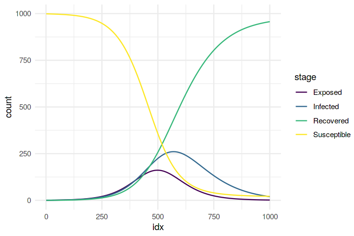

```r
ggplot(df, aes(idx, count, color=stage)) +
    geom_line() +
    scale_color_viridis_d() +
    theme_minimal()
```

In order to infer posterior distributions over parameters, I first add some noise to the simulated data. I do that by drawing from a Poisson using the simulated number of infected people per time interval.

```r
y_hat <- dplyr::filter(df, stage=='Infected') %>%
    dplyr::pull(count)
y <- rpois(length(y_hat), y_hat)
```

```r
stan.data <- list(
    n=n,
    n_population=n_population,
    y=y,
    t0=0,
    t=ts
)
```

Then we fit the model with Stan.

```r
stan.fit <- stan(file = seir.model.file, data=stan.data, iter=2000, chains=4, seed=23)
stan.fit
```

```
Inference for Stan model: seir_compartment_model.
4 chains, each with iter=2000; warmup=1000; thin=1;
post-warmup draws per chain=1000, total post-warmup draws=4000.

              mean se_mean   sd      2.5%      25%       50%       75%
theta[1]      2.17    0.00 0.12      1.88      2.1      2.19      2.25
theta[2]      0.86    0.00 0.11      0.73      0.8      0.84      0.90
theta[3]      0.50    0.00 0.00      0.50      0.5      0.50      0.50
s0            1.00    0.00 0.00      1.00      1.0      1.00      1.00
y0[1]         1.00    0.00 0.00      1.00      1.0      1.00      1.00
y0[2]         0.00     NaN 0.00      0.00      0.0      0.00      0.00
y0[3]         0.00    0.00 0.00      0.00      0.0      0.00      0.00
y0[4]         0.00     NaN 0.00      0.00      0.0      0.00      0.00
R0            4.32    0.01 0.22      3.78      4.2      4.35      4.47
lp__     386731.21    0.05 1.43 386727.51 386730.5 386731.51 386732.29
             97.5% n_eff Rhat
theta[1]      2.37   648 1.01
theta[2]      1.15   516 1.01
theta[3]      0.51   708 1.01
s0            1.00   978 1.00
y0[1]         1.00   978 1.00
y0[2]         0.00   NaN  NaN
y0[3]         0.00   978 1.00
y0[4]         0.00   NaN  NaN
R0            4.69   662 1.01
lp__     386733.02   907 1.00

Samples were drawn using NUTS(diag_e) at Sun Apr  5 16:25:24 2020.
For each parameter, n_eff is a crude measure of effective sample size,
and Rhat is the potential scale reduction factor on split chains (at
convergence, Rhat=1).
```

Looks good.

### Estimating $R_0$ on Basel SARS-CoV-2 case data

We download Basel case data from Zurich's open data GitHub account which gets updated regularly.

```r
uri <- "https://raw.githubusercontent.com/openZH/covid_19/master/fallzahlen_kanton_total_csv/COVID19_Fallzahlen_Kanton_BS_total.csv"
```

```r
basel.data <- readr::read_csv(uri) %>%
    dplyr::arrange(date) %>%
    dplyr::mutate(time = as.double(seq(n())))
```

The columns we are interested in are the numbers of infected people, called `ncumul_conf`, as well as the dates, called `date`.

```r
len <- length(basel.data$ncumul_conf)
basel.data$infected_per_day <- c(1, basel.data$ncumul_conf[2:len] - basel.data$ncumul_conf[1:(len - 1)])
basel.data[, c("date", "ncumul_conf", "infected_per_day", "time")]  %>%
    tail()
```

A tibble: 6 × 4

| date <date> | ncumul_conf <dbl> | infected_per_day <dbl> | time <dbl> |
| --- | --- | --- | --- |
| 2020-03-31 | 657 | 36 | 33 |
| 2020-04-01 | 691 | 34 | 34 |
| 2020-04-02 | 718 | 27 | 35 |
| 2020-04-03 | 758 | 40 | 36 |
| 2020-04-04 | 771 | 13 | 37 |
| 2020-04-05 | 794 | 23 | 38 |

Plot the number of cases in Basel:

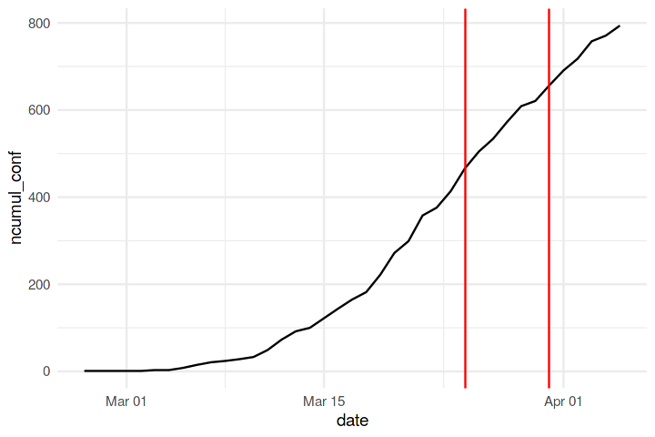

```r
ggplot2::ggplot() +
    geom_line(data=basel.data, aes(date, ncumul_conf)) +
    geom_vline(xintercept=as.Date("2020-03-31"), color="red") +
    geom_vline(xintercept=as.Date("2020-03-25"), color="red") +
    theme_minimal()
```

Looking at the numbers, it's obvious that our model cannot deal with this, since it looks as if the transmission rates change over time (for instance due to social distancing measures). Hence, we would need to model transmission as a time-dependent variable $\beta_t$. However, let's first try this simple model only the last couple of days. The "ausserordentliche Lage" of the Swiss government began earlier than this, so we could assume that the transmission is a constant.

```r
basel.data <- tail(basel.data, n=12)
basel.data[, c("date", "ncumul_conf", "infected_per_day", "time")]
```

A tibble: 12 × 4

| date <date> | ncumul_conf <dbl> | infected_per_day <dbl> | time <dbl> |
| --- | --- | --- | --- |
| 2020-03-25 | 466 | 52 | 27 |
| 2020-03-26 | 505 | 39 | 28 |
| 2020-03-27 | 534 | 29 | 29 |
| 2020-03-28 | 573 | 39 | 30 |
| 2020-03-29 | 609 | 36 | 31 |
| 2020-03-30 | 621 | 12 | 32 |
| 2020-03-31 | 657 | 36 | 33 |
| 2020-04-01 | 691 | 34 | 34 |
| 2020-04-02 | 718 | 27 | 35 |
| 2020-04-03 | 758 | 40 | 36 |
| 2020-04-04 | 771 | 13 | 37 |
| 2020-04-05 | 794 | 23 | 38 |

```r
stan.data <- list(
    n=length(basel.data$time),
    n_population= 200298, # https://en.wikipedia.org/wiki/Canton_of_Basel-Stadt at April 4th 2020
    y=basel.data$ncumul_conf,
    t0=0,
    t=basel.data$time
)
```

We fit the model, we an increased `adapt_delta` and `max_treedepth` to avoid divergences, low ESS, etc.

```r
stan.fit <- stan(file = seir.model.file, data=stan.data,
                 iter=5000, chains=2, seed=23,
                 control = list(adapt_delta = 0.99, max_treedepth = 15)
)
stan.fit
```

```
Inference for Stan model: seir_compartment_model.
2 chains, each with iter=5000; warmup=2500; thin=1;
post-warmup draws per chain=2500, total post-warmup draws=5000.

             mean se_mean   sd     2.5%      25%      50%      75%    97.5%
theta[1]     2.22    0.04 1.05     0.93     1.50     1.94     2.65     5.01
theta[2]     1.45    0.04 1.29     0.16     0.53     1.03     1.97     4.88
theta[3]     1.78    0.02 0.66     0.83     1.31     1.65     2.13     3.35
s0           1.00    0.00 0.00     1.00     1.00     1.00     1.00     1.00
R0           1.22    0.01 0.15     1.11     1.13     1.17     1.24     1.61
lp__     42149.11    0.06 1.64 42144.96 42148.34 42149.47 42150.29 42151.13
         n_eff Rhat
theta[1]   670    1
theta[2]   910    1
theta[3]   702    1
s0         606    1
R0         599    1
lp__       684    1

Samples were drawn using NUTS(diag_e) at Sun Apr  5 21:16:25 2020.
For each parameter, n_eff is a crude measure of effective sample size,
and Rhat is the potential scale reduction factor on split chains (at
convergence, Rhat=1).
```

We get zero divergent transitions (since we tuned the control list) and $\hat{R}$s of $1$. The estimated $R_0$ is around $1$, the initial proportion of suspectible $S_0$ is, as expected, also $1$. Let's plot the posteriors.

```r
samples <- extract(stan.fit)
samples <- data.frame(beta = samples$theta[,1], gamma = samples$theta[,3], R0 = samples$R0) %>%
    tidyr::gather("parameter", "value")
```

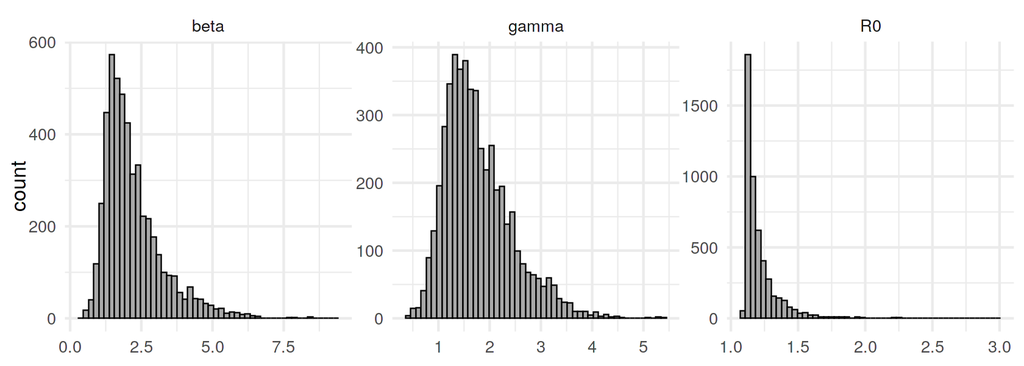

```r
options(repr.plot.width=14, repr.plot.height=5)
ggplot(samples) +
    geom_histogram(aes(value, fill=parameter), fill="darkgrey", color="black", bins=50) +
    facet_wrap(. ~ parameter, scales = "free") +
    theme_minimal(base_size = 20) +
    theme(axis.title.x = element_blank())
```

### Time-dependent $\beta_t$

The next step would be to allow $beta$ to change with time, in order to model the decrease of transmission rates, for instance due to social distancing or the like. We could model this, for instance, using a spline piece-wise linear spline.

##### This work is licensed under a [Creative Commons Attribution-NonCommercial 4.0 International License](http://creativecommons.org/licenses/by-nc/4.0/)